# Hierarchical Dirichlet Regression Model for Benthic Cover in the Abrolhos Bank

Pamela M. Chiroque-Solano  
Sciences Department at University of Lisboa, CE3C, Portugal  
Institute of Biology and SAGE-COPPE, Federal University of Rio de Janeiro, Brazil  
This work was done in collaboration with Mariana S. Sá and Larissa M. Martins.  
Joint Statistical Meetings virtual conference

11st of August, 2021

# Motivation

- Understanding the local **patterns** for the composition data of benthic coral reef dynamic in the Abrolhos bank;
- Investigating the **heterogeneity** of the multivariate response under different sites.

# Historical facts

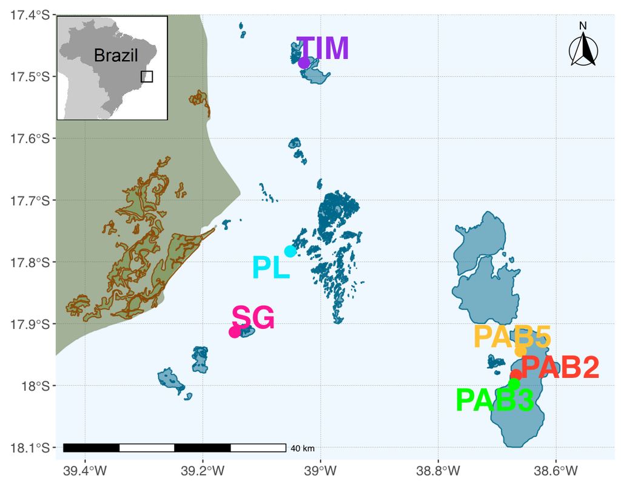

# Objectives

- To disassemble the composition via the **stochastic representation** for Dirichlet random vectors;
- To model the variability **effects by sites** including a hierarchical structure;
- To achieve **flexibility** with the proposed model, so that it can be useful in many settings.

# Proposal

- **Combined approach**: Compositional data model from (Maier 2014) and multilevel structure from (Gelman and Hill 2006);
- Filtered information through the **decomposition** of the Dirichlet distribution parameter into two components: **level and precision**;
- This **decomposition** allows us to obtain a **flexible** proposal.

# Notation

(Wang, Tian, and Tang 2011; Maier 2014)

- $y_{ic} \in (0,1)$: The proportion of coverage at observation $i$ of component $c$.
- $\sum_{c=1}^{C}y_{ic} = 1$: Constraint

**Assumptions**

- $\mathbf y \sim \mathcal{D}(\mathbf \alpha)$ on $C>2$-dimensional hyperplane or closed simplex $\mathbb{T}_{C}(1)$.
- $\alpha_c > 0$
- The Dirichlet’s probability density function:

$$\begin{eqnarray}
f(\mathbf y)&=& \frac{\Gamma(\alpha_{1}+\ldots+\alpha_{c})}{\prod _{c=1}^{C} \Gamma(\alpha_{c})} \prod _{c=1}^{C} y_{c}^{ \alpha_{c}-1}, \quad \sum_{c=1}^{C}y_c=1.
\end{eqnarray}$$

# Hierarchical Dirichlet regression under the Bayesian approach

Based on the **alternative parametrization** (Maier 2014; Holger and Sennhenn-Reulen 2018);

- $\mathbf Y_l \sim D(\mathbf\mu_l,\phi_l)$ with parameter $\alpha_{cl} = \mu_{cl}\phi_l$
- $\mu_{cl}$ : **level term**
- $\phi_{l}$ : **precision term**

$$\begin{eqnarray*}
\mu_{icl} = E(Y_{icl}\mid \mathbf x_i)&=&\frac{\exp( \mathbf x_i^{\prime}\mathbf\beta_{cl})}{\sum_{d=1}^{C}\exp(\mathbf x_i^{\prime}\mathbf\beta_{dl})}, \quad \mu_{icl}\in(0,1) \\ \nonumber
\phi_{il} &=& \exp(\mathbf z_i^{\prime}\theta_{l}), \quad \theta_{l} \in \mathbb{R} \nonumber \\
\beta_{cl} &=& \beta_{c}+ \epsilon_{\beta_{l}} \nonumber\\
\theta_{l} &=& \theta+ \epsilon_{\theta_{l}}
\end{eqnarray*}$$

# Reference component

- $\alpha_{cl} = \mu_{cl}\phi_l$
- $c^\star$ reference component should be chosen and $\mathbf\beta_{c^\star}$ is set to zero;
- For the $c^\star$ the expectation vector is given by

$$\mu_{ic^\star l} = \frac{1}{\sum_{d=1}^{C} \mu_{idl}}$$

- The reference dimension is chosen based on exploratory disassembling of components.

# Inference procedure

- Let $\Theta =(\mathbf\beta,\mathbf\phi)$ be the vector of parameters
- **Proper independent prior distribution** for the parametric vector $\mathbf{\Theta}$ are Normal with zero mean and precision $1/K$ for all effects of the model.
- The posterior distribution
  $$\begin{eqnarray}\label{posterior}
  \pi(\mathbf\Theta \mid \mathbf y) \propto L(\mathbf\Theta\mid \mathbf y)\prod_{l}^{L}\pi(\phi_l)\prod_{c}^{C}\pi(\beta_{cl})
  \end{eqnarray}$$
- Likelihood $L(\mathbf\Theta \mid {\mathbf y} )=\prod_{i=1}^{n}\prod_{l=1}^{L}f(\mathbf y_{il} \mid \mathbf\Theta)$.
- The joint posterior distribution does not have a known closed form;
- Sampling from the posterior distribution is done by Markov chain Monte Carlo (MCMC) via the Stan software.

# Aplication: Abrolhos bank

- **Reef Structures** (Teixeira, Chiroque-Solano, and al. 2021)

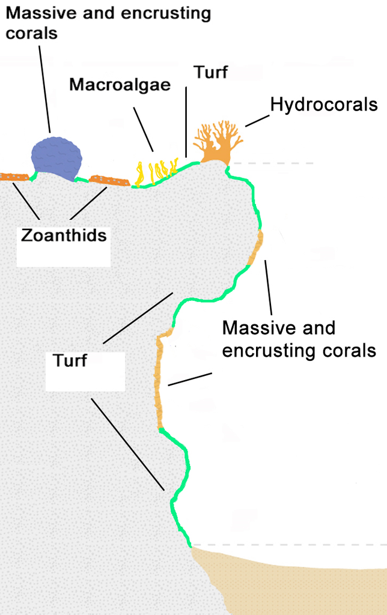

# **Reference component** (Wang, Tian, and Tang 2011)

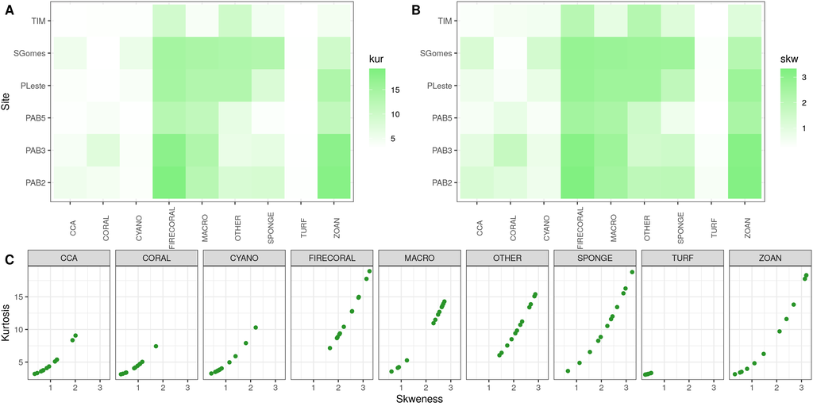

# Convergence checking

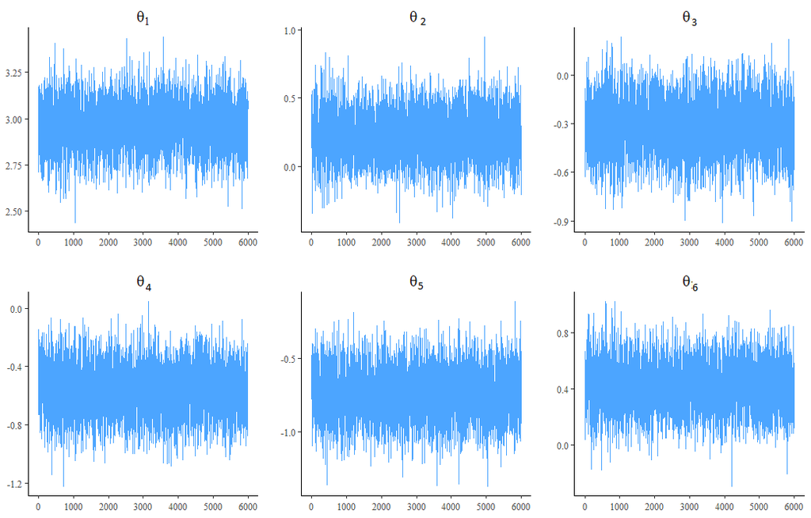

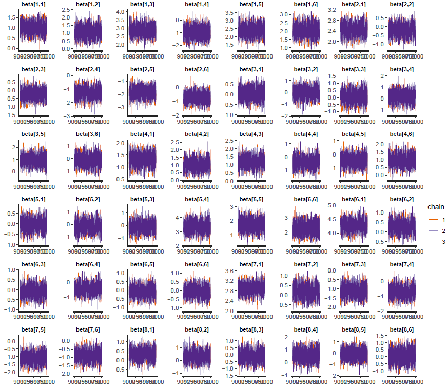

# Fitting the proposal: Posterior density of $\mathbf{\theta}$ effects

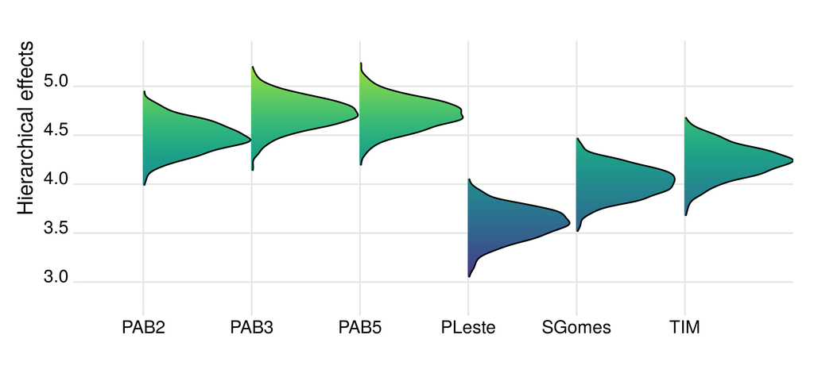

# Fitting the proposal: Posterior density of $\mathbf{\beta}$ effects

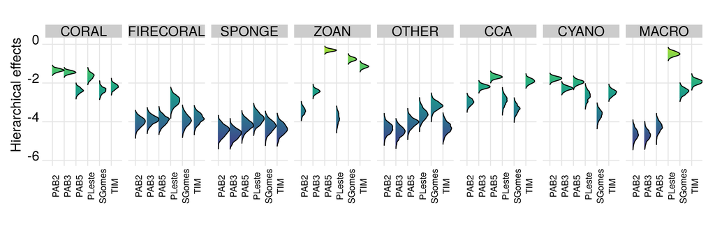

# Observed values against predicted values

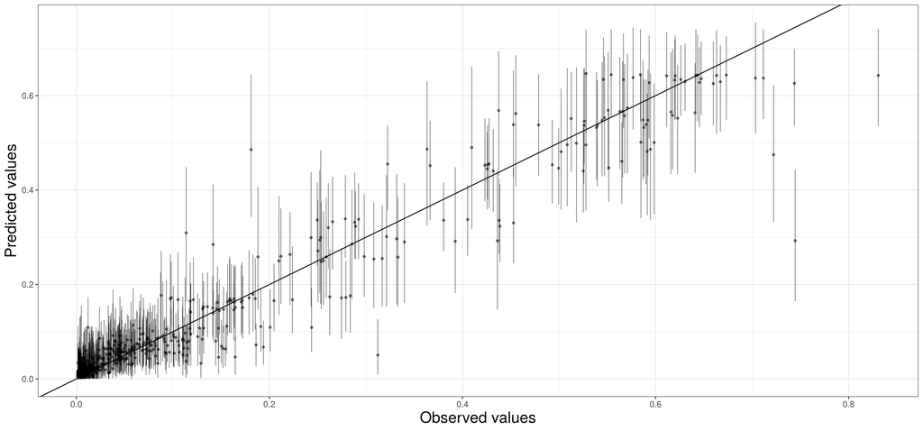

# Goodness-of-fit by site

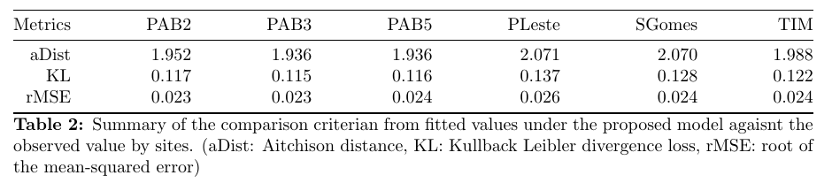

# Conclusion

- The proposed model quantifies the heterocedasticity through **precision effects via hierachical structures** by site;
- The **method is flexible**;
- The reference component has been chosen using **objective criteria**;
- The proposal allows to obtain **adequate predictions**.
- “Life Under Water”

# Thanks

- Foundation of Espírito Santo (Financial help)
- Guido Alberti Moreira (valuable suggestions)
- Organizing committee from the 2021 Joint Statistical Meetings
- Contact information: pamela@dme.ufrj.br

# References

Gelman, Andrew, and Jennifer Hill. 2006. *Data Analysis Using Regression and Multilevel/Hierarchical Models*. Analytical Methods for Social Research. Cambridge University Press. https://doi.org/10.1017/CBO9780511790942.

Holger, and Sennhenn-Reulen. 2018. “Bayesian Regression for a Dirichlet Distributed Response Using Stan.” ArXiv.org. https://arxiv.org/abs/1808.06399.

Maier, Marco J. 2014. “DirichletReg: Dirichlet Regression for Compositional Data in R.” Research Report Series/Department of Statistics and Mathematics 125. Vienna: WU Vienna University of Economics and Business. http://epub.wu.ac.at/4077/.

Teixeira, Carolina, Pamela Chiroque-Solano, and et al. 2021. “Decadal (2006-2018) Dynamics of Southwestern Atlantic’s Largest Turbid Zone Reefs.” *PLoS ONE* 16(2): 1–19. https://doi.org/10.1371/journal.pone.0247111.

Wang, K., G. Tian, and M Tang. 2011. *Dirichlet and Related Distributions: Theory, Methods and Applications*. Wiley Series in Probability; Statistics.